# Séance 1. Comparaison

# Comparison des caractéristiques des fleurs

Dans la série de données iris, on peut comparer les différentes valeurs des 4 variables des fleurs. L’objectif est de montrer les valeurs d’une ou de plusieurs variables en fonction des trois espèces.

## Bar plot

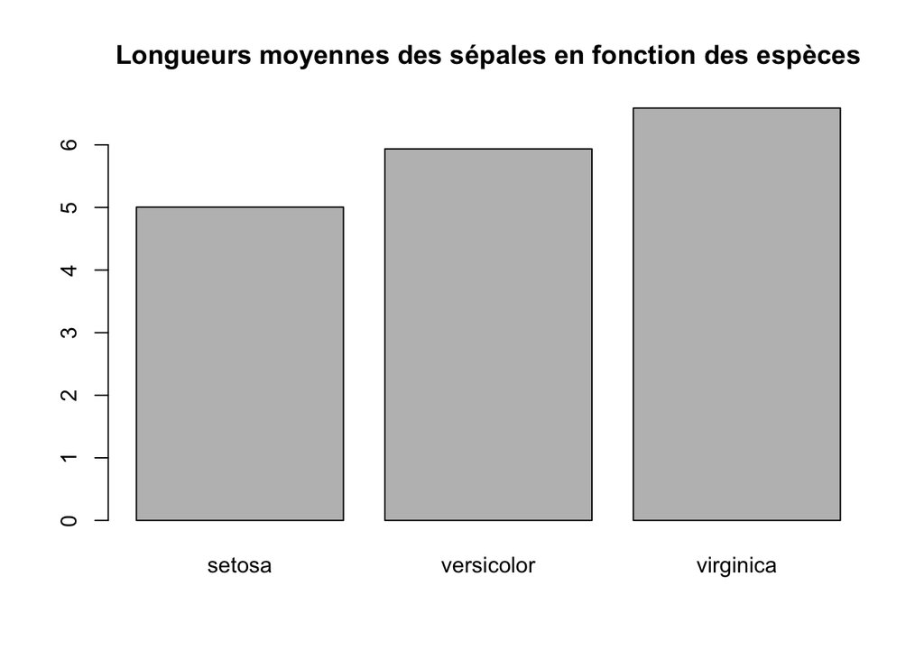

- Ajouter les volatilités de part et d’autre des moyennes
- Ajouter quelques quantiles
- Afficher plusieurs variables

## Boxplot

Le boxplot permet d’afficher quelques statistiques simples des variables. Identifier quelles sont les valeurs affichées.

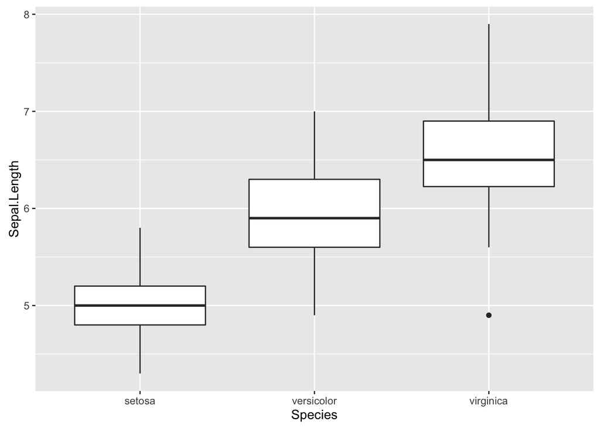

## Violin plot

Le violin plot permet de donner la forme des densités.

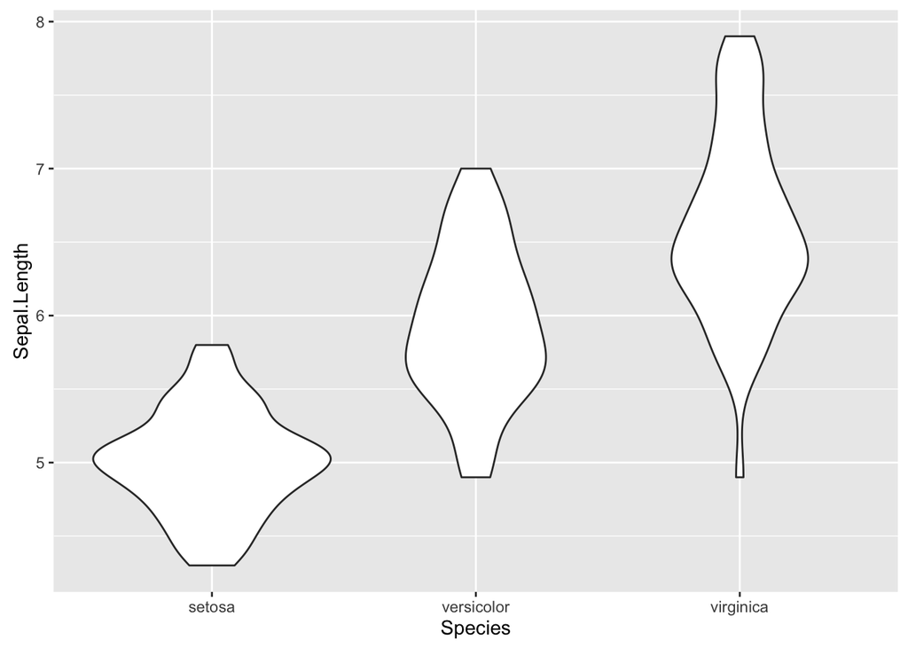

Rajouter les les statistiques de bases (moyenne, volatilité, quantiles) sur le violin plot.

## Tabplot

Pour ce graphique, utilisez le package `tabplot`.

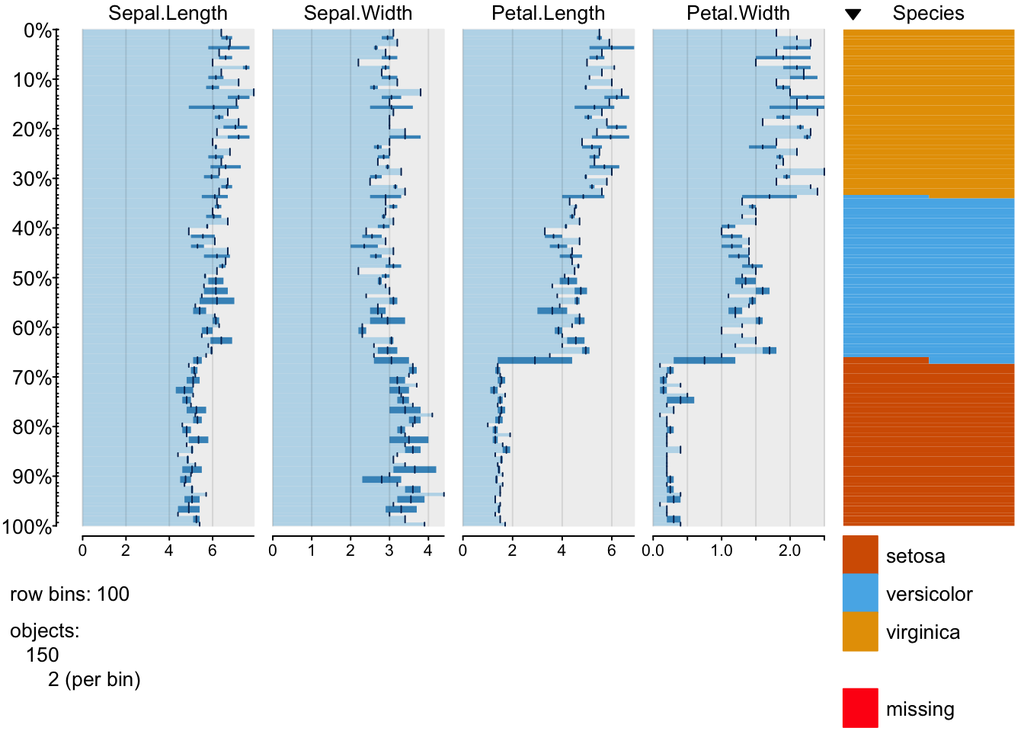

## Parallel Coordinates

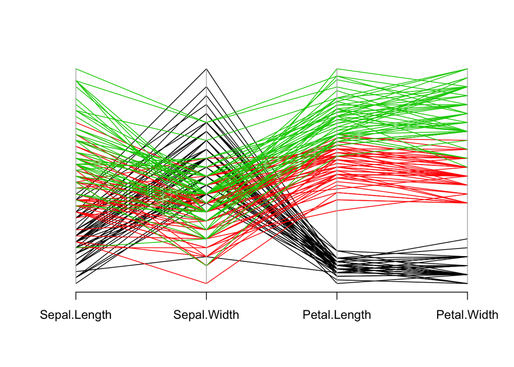

Rerchercher plusieurs façons de tracer ce type de graphiques.

# Evolution temporelle

## Line plot

Explorer et visualiser les différentes variables de la série de données `economics` (du package ggplots)

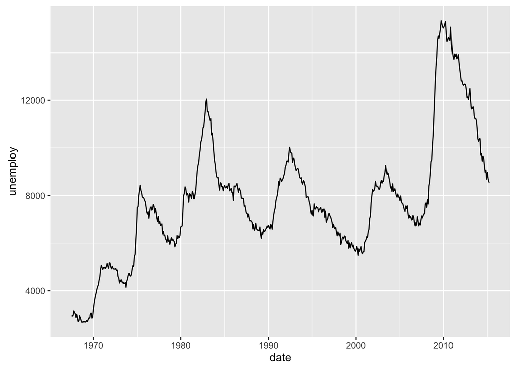

- Changer le type de lignes
- Changer la couleur
- Afficher plusieurs variables

## Un autre exemple

Explorer la série de données `manaus` du package `boot`.

- Visualiser l’évolution temporelle des données
- Visualiser de façon interactive la série de données avec le package `dygraphs`.
- Mettre en évidence la saisonnalité des données avec un graphique circulaire

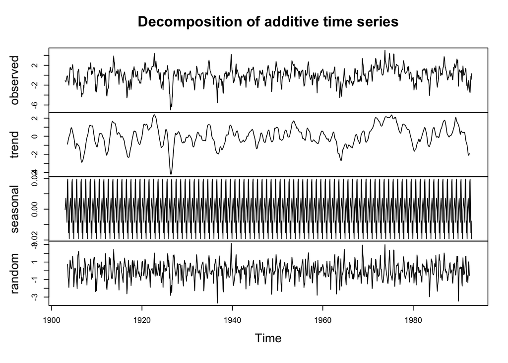

Copyright © 2016 DatavISUP